# Métodos Estatísticos

Métodos Estatísticos Gilberto Pereira Sassi Segundo semestre de 2022

## Cronograma – planejamento acadêmico das aulas

Cronograma de atividades por semana.

### Programa do componente curricular aprovado pela UFBA

[Programa da disciplina](https://est.ufba.br/sites/est.ufba.br/files/mat236_-_metodos_estatisticos.pdf)

## Horário do plantão de dúvidas

Toda terça-feira das 13h00min até às 14h00min na sala 220 do Instituto de Matemática e Estatística teremos uma plantão de dúvidas presencial comigo.

## Horário de *plantão de dúvidas* da monitoria

O monitor (remunerado) Luiz Antônio fará plantões de dúvidas nos seguintes dias e horários:

- Segunda-feira: das 13h00min até 14h50min na sala 120 do PAF-1.
- Quinta-feira: das 18h30min até 20h20min na sala 107 do PAF-1.
- Sexta-feira das 10h40min até 12h30min na [sala de atendimento on-line (google meet)](https://meet.google.com/qjj-vvvq-sav)

## Critério de avalição

Neste curso, teremos três tipos de avaliação: participação no fórum, atividades de fixação e provas. A nota dessas três atividades somadas totalizam 10 pontos, e você precisa conseguir cinco pontos, no mínimo, para ser aprovado na disciplina *Métodos Estatísticos*, conforme o [Regulamento de Ensino de Graduação e Pós-graduação da UFBA](https://www.ufba.br/sites/portal.ufba.br/files/Resolucao_n_012015_REGPG_atualizado_01-04-2015%29.pdf).

Neste curso, vamos seguir o que diz o [Regulamento de Ensino de Graduação e Pós-graduação da UFBA](https://www.ufba.br/sites/portal.ufba.br/files/Resolucao_n_012015_REGPG_atualizado_01-04-2015%29.pdf), ou seja, você estará automaticamente reprovada se faltar em 25% ou mais das 68 horas do nosso curso. Como cada aula nesta disciplina tem duas horas de duração, você pode faltar, no máximo, em oito aulas. A partir da nona falta, você está automaticamente reprovada.

Conforme decidido no primeiro dia de aula (16/08/2022). A média das provas valem 4 pontos em sua nota final, a média da nota de participação do Fórum vale 2 pontos em sua nota final e a média das atividades de fixação valem 4 pontos em sua nota final.

### Fórum

Este componente curricular dará pontuação por participação no *Fórum* em nosso espaço do AVA. A ideia é dar uma nota por semana de aula, e tirar uma média aritmética dessas notas semanais no final do semestre.

Conforme decidimos no primeiro dia de aula (dia 16/08/2022), se você fizer duas ou mais visualização (em dias diferentes) você terá nota 2 na semana, se você fizer uma única visualização na semana você terá nota 1 na semana, e se você não entrar no *Fórum* terá nota 0 na semana.

A nota final de participação no Fórum será a média das notas por semana de participação no Fórum.

### Atividades de fixação

Ao final de cada aula, terá um novo questionário que ficará disponível na seção **atividades de fixação** em nosso espaço do AVA e e as questões deste questionário abordarão o que foi visto em sala de aula. Para cada questionário, vocês terão 168 horas para responder, e a ideia é tirar uma média aritmética das notas das *atividades de fixação* no final do semestre.

Cada *atividade de fixação* terá nota máxima 4.

### Provas

Nosso curso terá duas provas com duração de 168 horas. As provas serão assíncronas, sem a presença do professor, e ficarão disponíveis na seção **provas** em nosso espaço do AVA. As datas das provas são:

- Data do início da primeira prova: 09/10/2022
- Data do início da segunda prova: 04/12/2022

Estas datas foram acordadas no primeiro dia de aula (16/08/2022), e só podem ser modificadas pelas estudantes com consenso entre todas discentes regularmente matriculadas no componente curricular.

Cada prova terá nota máxima 4.

## Conjunto de dados

- `companhia_MB.xlsx`

## Tabelas

- Tabela da distribuição normal
- Tabela da distribuição t-Student
- Tabela da distribuição qui-quadrado
- Tabela da distribuição F

## Slides e materiais

### Primeiro dia de aula

Primeiro dia de aula

### Unidades 1, 2 e 3

Estatística descritiva: tabelas, gráficos e medidas de resumo.

- Slides - tabelas e gráficos
- Slides - medidas de Resumo
- Lista de exercícios

### Unidade 4

Probabilidade e variável aleatória.

- Slides - probabilidade
- Slides - variável contínua
- Slides - variável discreta
- Lista de exercícios

### Unidade 5

Intervalo de confiança e teste de hipóteses para uma população (ou grupo).

- Slides - intervalo de confiança
- Slides - teste de hipóteses para uma população
- Lista de exercícios - intervalo de confiança
- Lista de exercícios - teste de hipóteses

### Unidade 6

Intervalo de confiança e teste de hipóteses para duas populações (ou grupos), teste de associação entre duas variáveis qualitativas e teste de associação entre duas variáveis quantitativas.

- Slides - intervalo de confiança e teste de hipóteses para 2 populações
- Lista de exercícios - 2 populações

### Unidade 7

Regressão linear simples e ANOVA.

- Slides - regressão linear simples
- Slide - ANOVA
- Lista de exercícios - regressão linear simples
- Lista de exercícios - ANOVA

## Número de faltas

- Número de faltas até o dia 23/11/2022

## Nota do Fórum

Nota semana por fórum conforme contrato didático no dia 16/08/2022, incluo abaixo a nota por semana do fórum.

- Semana 21/08/2022 a 27/08/2022
- Semana 28/08/2022 a 03/09/2022
- Semana 04/09/2022 a 10/09/2022
- Semana 11/09/2022 a 17/09/2022
- Semana 18/09/2022 a 24/09/2022
- Semana 25/09/2022 a 01/10/2022
- Semana 02/10/2022 a 08/10/2022
- Semana 09/10/2022 a 15/10/2022
- Semana 16/10/2022 a 22/10/2022
- Semana 23/10/2022 a 29/10/2022
- Semana 30/10/2022 a 05/11/2022
- Semana 06/11/2022 a 12/11/2022
- Semana 13/11/2022 a 19/11/2022
- Semana 20/11/2022 a 26/11/2022
- Semana 27/11/2022 a 03/12/2022

### Nota final do fórum

Nota final do Fórum

## Aula do dia 01/11/2022

A gravação da aula do dia 01/11/2022 está disponível no YouTube (como *não listado*). Na descrição do vídeo, eu inclui o link para a lousa da aula (usei a plataforma miro.com) e o arquivo excel que criamos na aula.

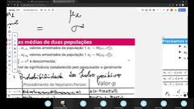

## Teste de Associação

Para te ajudar na atividade do dia 22/11/2022, realizei o teste de assoaciação entre variáveis qualitativas e variáveis quantitativas usando programa de planilhas: arquivo excel.

## Material complementar

### Introdução à Estatística usando a linguagem `R`

Vídeos explicando estatística básica usando a linguagem `R`. Os vídeos são antigos, foram gravados usando o microfone da minha webcam, foram gravados sem roteiro e estão sem edição. Então a qualidade deles é bem baixa, mas pode ser útil para alguém.

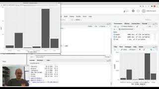

## Referências

### Referências principais

- MORETTIN, Pedro Alberto; BUSSAB, Wilton Oliveira. Estatística Básica. Editora Saraiva, 2017.
- MONTGOMERY, Douglas C.; RUNGER, George C. Applied Statistics and Probability for Engineers. John Wiley & Sons, 2010.

### Referências secundárias

- BARBETTA, Pedro Alberto. Estatística Aplicada às Ciências Sociais. Editora UFSC, 2008.
- KOTTEGODA, Nathabandu T.; ROSSO, Renzo. Applied statistics for civil and environmental engineers. 2008.